# Lecture #11: Stochastic Gradient Descent and Simulated Annealing

## AM 207: Advanced Scientific Computing

### Stochastic Methods for Data Analysis, Inference and Optimization

### Fall, 2019

[figure not shown]

## Administrative Matters

1. **Attendance Quiz:**

## Outline

1. Review of Logistic Regression & Gradient Descent
2. Stochastic Gradient Descent
3. Non-Convex Optimization
4. Simulated Annealing

# Review of Logistic Regression & Gradient Descent

## A New Model: Logistic Regression

A logistic regression model is just a Bernoulli model $Y^{(n)} \sim Ber(\theta_n)$ model, where $\theta^{(n)}$ depends on a set of covariates $\theta^{(n)} =\mathrm{sigm}(f(\mathbf{X}; \mathbf{w}))$. For now, we assume that $f(\mathbf{X}; \mathbf{w}) = \mathbf{w}^\top \mathbf{X}$.

**Question:** What's the big deal about modeling with covariates?

## General Linear Models

We can add covariates to all the other common statistical models of data $Y^{(n)} \sim p(Y^{(n)}|\theta^{(n)})$!

The general scheme is:

1. Set $\mathbb{E}[Y^{(n)}] = \theta^{(n)} = g(\mathbf{w}^\top \mathbf{X}^{(n)})$, where $g$ is typically a non-linear function called the *link function* (in literature, $g^{-1}$ is called the link function).
2. Set the variance according to how the variance of $p(Y^{(n)}|\theta^{(n)})$ depends on $\theta$, $\mathrm{Var}[Y^{(n)}] = \phi f(\theta^{(n)})$, where $\phi$ is a constant.

**For example:** If $Y^{(n)} \sim Poi(\lambda^{(n)})$, we know that $\mathbb{E}[Y^{(n)}] = \mathrm{Var}[Y^{(n)}] = \lambda^{(n)}$. So we can replace $\lambda^{(n)}$ with a linear function of $\mathbf{X}$:

$$ \lambda^{(n)} = e^{\mathbf{w}^\top \mathbf{X}^{(n)}}. $$

The link function we chose is $e^x$, can you see why we made this choice?

## A New Inference Algorithm: Maximum Likelihood by Gradient Descent

We'd like to learn the parameters $\mathbf{w}_{\text{MLE}} = \underset{\mathbf{w}}{\mathrm{argmin}} \left(-\ell(\mathbf{w})\right)$. The derivative $\nabla_\mathbf{w} \left(-\ell(\mathbf{w})\right)$ is easy to derive but hard to solve for stationary points!

**Gradient descent:** we algorithmically find $\mathbf{w}^*$ such that the derivative $\nabla_\mathbf{w} \left(-\ell(\mathbf{w})\right)(\mathbf{w}^*)$ is approximately zero:

1. start at any $\mathbf{w}^{(0)}$
2. compute: $\nabla_\mathbf{w} \left(-\ell(\mathbf{w})\right)$ at $\mathbf{w}^{(current)}$
3. take a step in the negative gradient direction: $\mathbf{w}^{(new)} \leftarrow \mathbf{w}^{(current)} - \eta * \nabla_\mathbf{w} \left(-\ell(\mathbf{w})\right)(\mathbf{w}^{(current)})$

We repeat until the derivative is close to zero (stationary).

This algorithm *"solves for"* the stationary point of $\nabla_\mathbf{w} \left(-\ell(\mathbf{w})\right)$ for us!

**Question:** Can we use gradient descent to solve other hard optimization problem we've seen in this class?

## Subtleties of Gradient Descent: Step Size Matters

If the objective function is *convex* and *L-Lipschitz* then you can choose $\eta$ such that gradient descent provably converges, you can also derive the *rate of convergence*.

If you know nothing about the objective function, then you choose $\eta$ by intelligent "guess-and-check".

[figure not shown]

## Subtlties of Gradient Descent: Local vs Global Minima

If the objective function is *convex* and the constraints define a *convex feasible set*, then a stationary point of the objective function gradient or Lagrangian gradient is also a global minimum of the optimization problem.

If the optimization problem is nonconvex then *there is no guarantee* that when gradient descent converges, you've found anything close to a global minimum!

[figure not shown]

## Where does Non-Convexity Come From?

1. (**Link Functions**) General linear models with monotone increasing link functions have convex negative log-likelihoods (with respect to a specific parametrization). However, in some cases, we may wish to choose link functions that are not monotone increasing.
2. (**Constraints**) Often, we maximize constrained (or regularized) version of the likelihood. These constraints may not always define convex feasible sets.
3. (**Non-Linear Dependency on $\mathbf{w}$**) In our logistic regression model, $Y^{(n)} \sim Ber(\mathrm{sigm}(f(\mathbf{X}; \mathbf{w})))$, we can choose a function $f$ that is non-linear in $\mathbf{w}$ (it'll be a neural network later).

## Subtlties of Gradient Descent: Scalability

For every likelihood optimization problem, evaluating the gradient at a set of parameters $\mathbf{w}$ requires evaluating the likelihood of the entire dataset using $\mathbf{w}$:

$$ \nabla_{\mathbf{w}} \ell(\mathbf{w}) = -\sum_{n=1}^N \left(y^{(n)} - \frac{1}{1 + e^{-\mathbf{w}^\top\mathbf{x}^{(n)}}} \right) \mathbf{x}^{(n)} =\mathbf{0} $$

Imagine if the size of your dataset $N$ is in the millions. Naively evaluating the gardient **just once** may take up to seconds or minutes, thus running gradient descent until convergence may be unachievable in practice!

**Idea:** Maybe we don't need to use the entire data set to evaluate the gradient during each step of gradient descent. Maybe we can approximate the gradient at $\mathbf{w}$ well enough with just a subset of the data.

# Stochastic Gradient Descent

## Mini-batch Evaluation of the Gradient

Rather than computing the gradient of the negative log-likelihood at every $\mathbf{w}$ using the entire dataset, we can **approximate** the true gradient at $\mathbf{w}$ by computing the gradient of the negative log-likelihood using a subset of $N/K$ number of observations.

This modified gradient descent algorithm is called *mini-batch gradient descent*:

1. Start at initial value $\mathbf{w}^{(0)}$.
2. For `epochs` $= 1, \ldots, $ `total_epochs`:
   1. Shuffle the data and divide up into $K$-chunks each with $N/K$ observations
   2. For $k =1, \ldots K$:
      1. Compute `grad`$(\mathbf{w}) = -\nabla_{\mathrm{w}} \prod_{n=1}^{N/K} p(y^{(n)} |\mathrm{x}^{(n)}, \mathbf{w})$, where $y^{(n)}, \mathrm{x}^{(n)}$ are from the $k$-th chunk.
      2. Evaluate `grad`$(\mathbf{w}^{(current)})$.
      3. Set $\mathbf{w}^{(new)} \leftarrow \mathbf{w}^{(current)} - \eta *$ `grad`$(\mathbf{w}^{(current)})$

In the extreme case, we choose each chunk to have only 1-observation, the algorithm reduces to randomly selecting an observation to compute the gradient in each iteration.

## Mini-batch Evaluation as Stochastic Gradients

Since the gradient of the negative log-likelihood in each iteration is **approximated** using a random subset of the data, this approximation introduces *stochasticity* into the descent algorithm. That is, we can reframe mini-batch gradient descent as *stochastic gradient descent*:

1. Start at initial value $\mathbf{w}^{(0)}$.
2. Compute: $\nabla_\mathbf{w} \left(-\ell(\mathbf{w})\right)$ at $\mathbf{w}^{(current)}$
3. Take a **stochastic step** in the negative gradient direction: $\mathbf{w}^{(new)} \leftarrow \mathbf{w}^{(current)} - \eta * \nabla_\mathbf{w} \left(-\ell(\mathbf{w})\right)(\mathbf{w}^{(current)}) + \epsilon$

where $\epsilon\sim p(\epsilon)$ is a random variable with mean zero.

If the negative log-likelihood is convex and we can compute the variance of $p(\epsilon)$, we can again prove that stochastic gradient descent (and hence mini-batch gradient descent) converges to the global minimum for an appropriate choice of $\eta$.

## Maximum Likelihood with Stochastic Gradient Descent

What is the difference between the performance of gradient descent and that of stochastic gradient descent on the logistic regression model? Which type of descent should we use for these models?

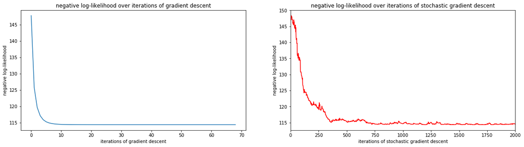

```python
fig, ax = plt.subplots(1, 2, figsize=(20, 5))
ax = plot_diagnostics(ax, nlls, nlls_s)
plt.show()
```

# Non-Convex Optimization

## A Non-Convex Optimization Example

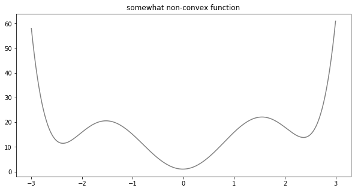

```python
#plot our somewhat non-convex function
fig, ax = plt.subplots(1, 1, figsize=(10, 5))
ax.plot(x, g(x), color='gray')
ax.set_title('somewhat non-convex function')
plt.show()
```

## Gradient Descent for Non-Convex Optimization

How would gradient descent perform when minimizing a non-convex objective function?

```python
animated_descent
```

[video not shown]

## Stochastic Optimization for Non-Convex Optimization

How would stochastoic gradient descent perform when minimizing a non-convex objective function?

```python
aninimated_descent_noisy
```

[video not shown]

## Another Non-Convex Optimization Example

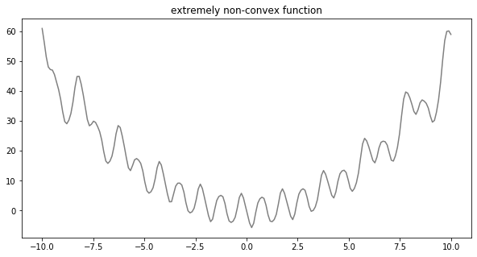

```python
#plot our extremely non-convex function f
fig, ax = plt.subplots(1, 1, figsize=(10, 5))
ax.plot(x, f(x), color='gray')
ax.set_title('extremely non-convex function')
plt.show()
```

## Stochastic Optimization for Non-Convex Optimization

How would gradient descent perform when minimizing a non-convex objective function?

```python
aninimated_descent_2
```

[video not shown]

## The Idea of Monte Carlo Optimization

Let's take inspiration from another stochastic algorithm that blended exploring randomly and exploiting known and highly desirable regions: Metropolis-Hastings.

In MH, random exploration exploration is implemented by a proposal distribution. We always accept if the proposed point is more likely than the current, but sometime we accept a less likely point -- this is what allows us to jump to a new region in the sample space.

If our objective function were a pdf, then MH is guaranteed to visit every point with non-zero likelihood asymptotically!

## The Idea of Simulated Annealing

1. Turn the objective function $f(x)$ into a pdf $p(x)$, but with higher mass where $f$ has lower values. This is the *Gibbs distribution*: $$ p(x) \propto \exp\left\{ -\frac{f(x)}{T}\right\},\;\; T \text{ is a constant} $$ **Note:** $p(x)$ isn't always a proper pdf!
2. Use a MH-algorithm with a symmetric proposal distribution to sample values of $x$ based on $p(x)$ -- MH will be incentivized by $p(x)$ to sample more $x$-values where $f(x)$ is small! The accept probability is:

$$ \alpha(x_{\text{proposal}}, x_{\text{old}}) = \min \left(1, \exp\left\{ -\frac{f(x_{\text{proposal}}) - f(x_{\text{old}})}{T}\right\}\right) $$

1. To control exploration vs exploitation, we start with large $T$ and decrease slowly:
   - when $T$ is large, $\exp\left\{ -\frac{f(x_{\text{proposal}}) - f(x_{\text{old}})}{T}\right\}$ is close to 1
   - when $T$ is small, $\exp\left\{ -\frac{f(x_{\text{proposal}}) - f(x_{\text{old}})}{T}\right\}$ is close to 0 if $f(x_{\text{proposal}}) > f(x_{\text{old}})$.

## Design Choices in Simulated Annealing

1. Temperature decreasing schedule
2. Number of MH-steps to take for each temperature.

   As the temperature descreases we should sample more and more. Why?

[figure not shown]

## The Simulated Annealing Algorithm

1. intialize anywhere $x^{(0)}$, intitialize temperature `T_0` and `number_of_samples`
2. for `epoch` $= 1, \ldots$ `total_epochs`
   1. for `i` $=1, \ldots$ `number_of_samples`
      1. propose $x_{\text{proposal}}$ from proposal distribution
      2. compute accept probability $\alpha(x_{\text{proposal}}, x_{\text{old}})$
      3. accept $x_{\text{proposal}}$ or keep $x_{\text{old}}$ randomly based on $\alpha(x_{\text{proposal}}, x_{\text{old}})$.
   2. decrease temperature by cooling schedule
   3. increase `number_of_samples` by schedule

## Simulated Annealing for Non-Convex Optimization

```python
#see where the minimum found by SA is
accumulator_sorted = sorted(accumulator, key=lambda t: t[2])
print('we found the minimum of {} at temperature {}'.format(accumulator_sorted[0][2][0], accumulator_sorted[0][0]))
```

```
we found the minimum of -5.698015529746401 at temperature 2.097152000000001
```

```python
aninimated_sa
```

[video not shown]